# Mestrado em Hemoterapia: Bioestatística

## Introdução

Testes de permutação/aleatorização podem ser utilizados para avaliar hipóteses sobre efeitos de tratamentos, quando as unidades experimentais são alocadas aleatoriamente para cada tratamento.

**Exemplo:** Um grupo de pesquisadores quer avaliar se dois tratamentos, \(A\) e \(B\) apresentam diferença com relação a uma certa resposta de interesse.

Os pesquisadores têm à disposição 6 pessoas.

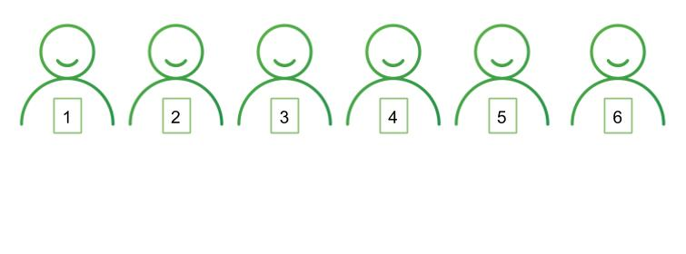

## Exemplo

As 6 pessoas são alocadas, aleatoriamente, a um dos tratamentos:

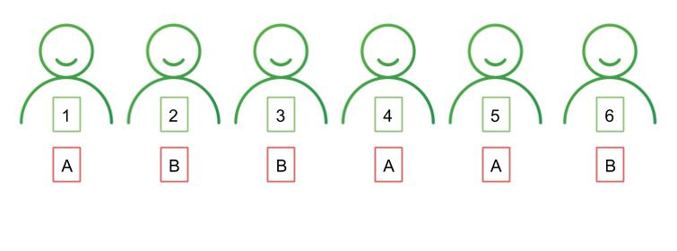

## Exemplo

Após aplicar o tratamento, coletamos a variável resposta de interesse em cada pessoa.

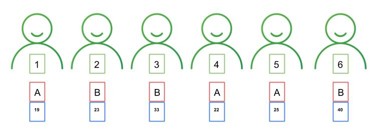

## Exemplo

Dados observados:

| ID | Tratamento | Resposta |
| --- | --- | --- |
| 1 | A | 19 |
| 2 | B | 23 |
| 3 | B | 33 |
| 4 | A | 22 |
| 5 | A | 25 |
| 6 | B | 40 |

## Exemplo

- \(\bar{x}_A = 22\)
- \(\bar{x}_B = 32\)
- Diferença entre \(A\) e \(B\) é -10.
- Esta diferença indica que \(A\) tem média inferior à \(B\) (pensando populacionalmente, não apenas na nossa amostra)?
- Seria possível, mesmo que não houvesse diferença entre os tratamentos, observar uma diferença de -10? Isto é, a diferença observada foi devido ao acaso? Ou foi devido ao fato de realmente existir uma diferença entre os tratamentos?

## Exemplo

- \(H_0\): não há diferença entre os tratamentos
- \(\mu_A\) a verdadeira média das respostas do Tratamento \(A\)
- \(\mu_B\) a verdadeira média das respostas do Tratamento \(B\)
- \(H_0\): \(\mu_A=\mu_B\).
- Como avaliar?

## Exemplo

Sob \(H_0\), não existe diferença entre os tratamentos.

Se \(H_0\) é verdadeira, então a resposta de cada pessoa não tem ligação com o tratamento que ela recebeu.

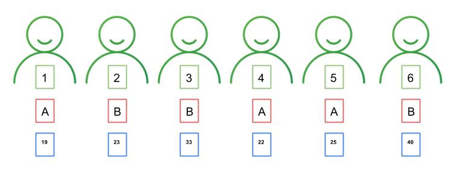

## Exemplo

Se \(H_0\) é verdadeira, a diferença observada de -10, foi apenas consequência de uma alocação aleatória em dois grupos \(A\) e \(B\).

Iremos, desta forma, repetir o argumento da \(H_0\): avaliar todas as alocações aleatórias possíveis e 6 pessoas entre os Tratamentos \(A\) e \(B\) e calcular a diferença.

## Exemplo

Quantas maneiras temos de escolher ao acaso 3 pessoas, de um grupo de 6?

\[\binom{6}{3}=20\]

Temos 20 maneiras de alocar 3 pessoas para o tratamento \(A\) e as restantes para o tratamento \(B\).

## Exemplo

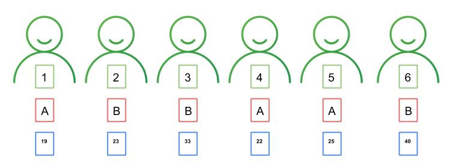

|  | Pessoa 1 do Trat A | Pessoa 2 do Trat A | Pessoa 3 do Trat A | Média do Trat A | Média do Trat B | Diferença entre A e B |
| --- | --- | --- | --- | --- | --- | --- |
| 8 | 1 | 4 | 5 | 22 | 32 | -10 |

## Exemplo

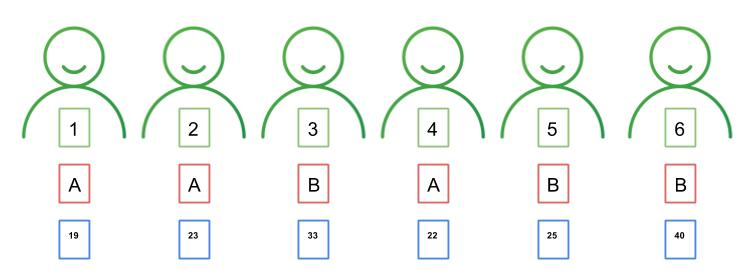

|  | Pessoa 1 do Trat A | Pessoa 2 do Trat A | Pessoa 3 do Trat A | Média do Trat A | Média do Trat B | Diferença entre A e B |
| --- | --- | --- | --- | --- | --- | --- |
| 2 | 1 | 2 | 4 | 21.33 | 32.67 | -11.34 |

## Exemplo

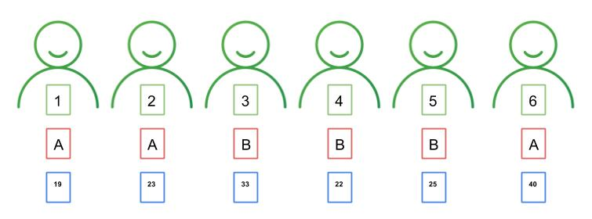

|  | Pessoa 1 do Trat A | Pessoa 2 do Trat A | Pessoa 3 do Trat A | Média do Trat A | Média do Trat B | Diferença entre A e B |
| --- | --- | --- | --- | --- | --- | --- |
| 4 | 1 | 2 | 6 | 27.33 | 26.67 | 0.66 |

## Exemplo

| Pessoa 1 do Trat A | Pessoa 2 do Trat A | Pessoa 3 do Trat A | Média do Trat A | Média do Trat B | Diferença entre A e B |
| --- | --- | --- | --- | --- | --- |
| 1 | 2 | 3 | 25.00 | 29.00 | -4.00 |
| 1 | 2 | 4 | 21.33 | 32.67 | -11.34 |
| 1 | 2 | 5 | 22.33 | 31.67 | -9.34 |
| 1 | 2 | 6 | 27.33 | 26.67 | 0.66 |
| 1 | 3 | 4 | 24.67 | 29.33 | -4.66 |
| 1 | 3 | 5 | 25.67 | 28.33 | -2.66 |
| 1 | 3 | 6 | 30.67 | 23.33 | 7.34 |
| 1 | 4 | 5 | 22.00 | 32.00 | -10.00 |
| 1 | 4 | 6 | 27.00 | 27.00 | 0.00 |
| 1 | 5 | 6 | 28.00 | 26.00 | 2.00 |

## Exemplo

|  | Pessoa 1 do Trat A | Pessoa 2 do Trat A | Pessoa 3 do Trat A | Média do Trat A | Média do Trat B | Diferença entre A e B |
| --- | --- | --- | --- | --- | --- | --- |
| 11 | 2 | 3 | 4 | 26.00 | 28.00 | -2.00 |
| 12 | 2 | 3 | 5 | 27.00 | 27.00 | 0.00 |
| 13 | 2 | 3 | 6 | 32.00 | 22.00 | 10.00 |
| 14 | 2 | 4 | 5 | 23.33 | 30.67 | -7.34 |
| 15 | 2 | 4 | 6 | 28.33 | 25.67 | 2.66 |
| 16 | 2 | 5 | 6 | 29.33 | 24.67 | 4.66 |
| 17 | 3 | 4 | 5 | 26.67 | 27.33 | -0.66 |
| 18 | 3 | 4 | 6 | 31.67 | 22.33 | 9.34 |
| 19 | 3 | 5 | 6 | 32.67 | 21.33 | 11.34 |
| 20 | 4 | 5 | 6 | 29.00 | 25.00 | 4.00 |

## Exemplo

Todas as diferenças obtidas através de alocação ao acaso nos tratamentos:

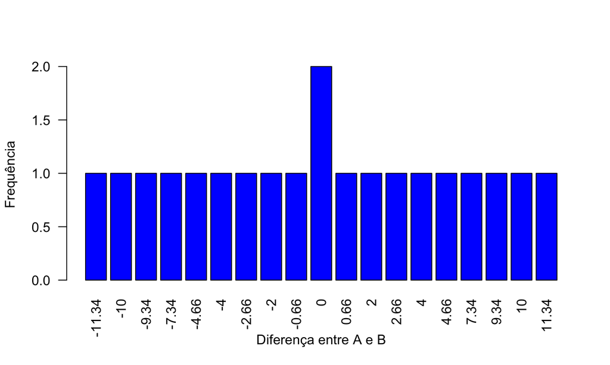

## Exemplo

A diferença observada foi de -10.

Sob \(H_0\), obteríamos uma diferença de \(|-10|\) ou ainda maior, em valor absoluto, 4 vezes.

Como temos 20 combinações possíveis e apenas 4 com valores iguais ou mais extremos ao valor de diferença observada no experimento, temos que o p-valor é:

\[ \frac{4}{20}=0.2 \]

Desta maneira, uma valor de diferença como o observado ou ainda mais extremo pode ocorrer ao acaso com probabilidade 0.20. Os dados portanto não trazem evidências para rejeitar a hipótese de que não há diferença entre os tratamentos.

## Exemplo

Se utilizarmos o teste *t-student* para duas amostras (variâncias iguais):

```
##
##  Two Sample t-test
##
## data:  Resposta by Tratamento
## t = -1.9127, df = 4, p-value = 0.1283
## alternative hypothesis: true difference in means is not equal to 0
## 95 percent confidence interval:
##  -24.515613   4.515613
## sample estimates:
## mean in group A mean in group B
##              22              32
```

## Exemplo

Se utilizarmos o teste *t-student* para duas amostras (variâncias diferentes):

```
##
##  Welch Two Sample t-test
##
## data:  Resposta by Tratamento
## t = -1.9127, df = 2.4858, p-value = 0.1704
## alternative hypothesis: true difference in means is not equal to 0
## 95 percent confidence interval:
##  -28.765539   8.765539
## sample estimates:
## mean in group A mean in group B
##              22              32
```

## Exemplo 2

Um grupo de pesquisadores quer avaliar se dois tratamentos, \(A\) e \(B\) apresentam diferença com relação a uma certa resposta de interesse.

> Os pesquisadores têm à disposição 20 pessoas.

As 20 pessoas são alocadas, aleatoriamente, a um dos tratamentos.

Após aplicar o tratamento, coletamos a variável resposta de interesse em cada pessoa.

## Exemplo 2

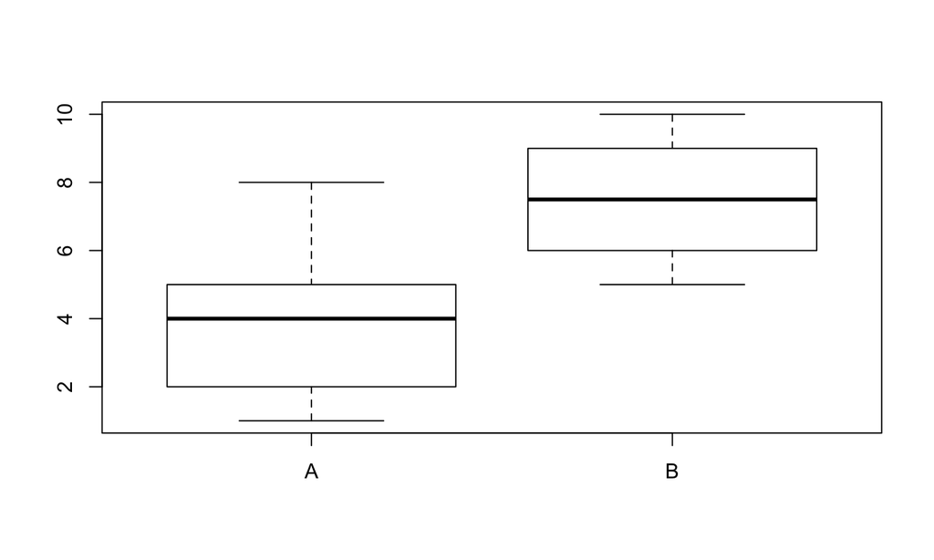

## Exemplo 2

Dados observados:

- \(\bar{x}_A = 4.1\)
- \(\bar{x}_B = 7.4\)
- Diferença entre \(A\) e \(B\) é -3.3.
- Esta diferença indica que \(A\) tem média inferior à \(B\) (pensando populacionalmente, não apenas na nossa amostra)?
- Seria possível, mesmo que não houvesse diferença entre os tratamentos, observar uma diferença de -3.3? Isto é, a diferença observada foi devido ao acaso? Ou foi devido ao fato de realmente existir uma diferença entre os tratamentos?

## Exemplo 2

Quantas maneiras temos de escolher ao acaso 10 pessoas, de um grupo de 20?

> \[\binom{20}{10}=1.84756\times 10^{5}\]

> Temos \(1.84756\times 10^{5}\) maneiras de alocar 10 pessoas para o tratamento \(A\) e as restantes para o tratamento \(B\).

## Exemplo 2

Todas as diferenças obtidas através de alocação ao acaso nos tratamentos:

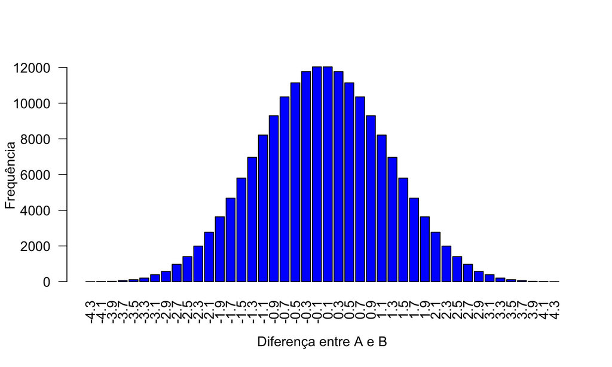

## Exemplo 2

P-valor: diferenças iguais ou maiores, em valor absoluto, do que o valor absoluto da diferença observada, \(|-3.3|\).

P-valor: \(0.0043842\)

## Exemplo 2

Se utilizarmos o teste *t-student* para duas amostras (variâncias iguais):

```
##
##  Two Sample t-test
##
## data:  Resposta by Tratamento
## t = -3.5156, df = 18, p-value = 0.00247
## alternative hypothesis: true difference in means is not equal to 0
## 95 percent confidence interval:
##  -5.272083 -1.327917
## sample estimates:
## mean in group A mean in group B
##             4.1             7.4
```

## Exemplo 2

Se utilizarmos o teste *t-student* para duas amostras (variâncias diferentes):

```
##
##  Welch Two Sample t-test
##
## data:  Resposta by Tratamento
## t = -3.5156, df = 17.418, p-value = 0.002573
## alternative hypothesis: true difference in means is not equal to 0
## 95 percent confidence interval:
##  -5.27682 -1.32318
## sample estimates:
## mean in group A mean in group B
##             4.1             7.4
```

## Passo-a-passo

- \(H_0\): \(\mu_A=\mu_B\)
- Aloque as pessoas em um dos dois tratamentos, aleatoriamente: \(m\) alocados ao Tratamento A e \(n\) alocados ao Tratamento \(B\)
- Calcule a média para cada tratamento: \(\bar{x}_A\) e \(\bar{x}_B\)
- Calcule a diferença entre as médias: \(D_{obs}=\bar{x}_A-\bar{x}_B\)
- Permute as \(m+n\) observações entre os dois tratamentos, obtenha uma lista com todas as permutações possíveis:

\[\binom{m+n}{m}=\frac{(m+n)!}{m!n!}\]

## Passo-a-passo

- Para cada permutação, calcule \(D\), a diferença entre as médias dos tratamentos.
- Encontre o p-valor:
  - \(H_a\): \(\mu_A>\mu_B\)

  \[\mbox{p-valor}=\frac{\# \{D \geq D_{obs}\}}{\binom{m+n}{m}}\]
  - \(H_a\): \(\mu_A<\mu_B\)

  \[\mbox{p-valor}=\frac{\#\{ D \leq D_{obs}\}}{\binom{m+n}{m}}\]
  - \(H_a\): \(\mu_A\neq\mu_B\)

  \[\mbox{p-valor}=\frac{\#\{ |D| \geq |D_{obs}|\}}{\binom{m+n}{m}}\]

## Leituras

- [Zieffler et al.](http://onlinelibrary.wiley.com/book/10.1002/9781118063682): capítulo 6.

Slides produzidos pelos professores:

- Samara Kiihl
- Tatiana Benaglia
- Benilton Carvalho
- Rafael Maia